BACK TO SCHEDULE

- Point Estimator
- Confidence Interval
- C.I. for a Population Proportion
- C.I. for a Population Mean
- Confidence Interval in R

# Point Estimator

A **parameter** is a numerical summary of a population, such as the population mean, $\mu$, or a population proportion, p.

A **point estimate** is a single number that is used to estimate the value of an unknown parameter.

- The sample mean score for the 100 students was $\bar{X}$ = 67.30.
- The administrators want to *estimate* what the mean score $\mu$ “would be” if the entire population of fourth graders in the district ad enrolled in the program.
- The best estimate for the population mean is the *sample mean*, $\bar{X}$ = 67.30.

The sample mean, $\bar{X}$, is a **point estimate** because it is a single number.

# Confidence Interval

A **confidence interval** is an interval that is used to *estimate* the value of a parameter.

In a random sample of 400 students at a university, 320 stated that they were nonsmokers. Based on this sample, compute a 90% confidence interval for the proportion of all students at the university who are nonsmokers. Then find the lower limit and upper limit of the 90% confidence interval.

A confidence interval for an unknown parameter consists of an **interval of numbers** based on the point estimate: Point Estimate $\pm$ Margin of Error.

The **confidence level** is a percentage between 0% and 100% that measures the success rate of the method used to construct a confidence interval. If we were to draw many samples and use each one to construct a confidence interval, then **in the long run**, the percentage of confidence intervals that cover the true value would be equal to the confidence level.

# Large Sample Confidence Interval for a Population Proportion

When **n** is large, a 95% confidence interval for p is

$\hat{p} - 1.96\sqrt{\frac{\hat{p}(1 - \hat{p})}{n}}, \hat{p} + 1.96\sqrt{\frac{\hat{p}(1 - \hat{p})}{n}}$; where $\hat{p}$ is the sample proportion.

Abbreviated formula: $\hat{p} \pm 1.96\sqrt{\frac{\hat{p}(1 - \hat{p})}{n}}$

The interval can be used as long as:

- $n\hat{p} \geq 10$ and $n(1 - \hat{p}) \geq 10$
- The sample can be regarded as a random sample from the population of interest.

The expression $1.96\sqrt{\frac{\hat{p}(1 - \hat{p})}{n}}$ is the **margin of error** for 95% confidence level. Other commonly used confidence levels, 90% and 99%, use Z critical values 1.645 and 2.58 respectively.

In a random sample of 400 students at a university, 320 stated that they were nonsmokers. Based on this sample, compute a 90% confidence interval for the proportion of all students at the university who are nonsmokers. Then find the lower limit and upper limit of the 90% confidence interval.

- Formula: $\hat{p} \pm 1.645\sqrt{\frac{\hat{p}(1 - \hat{p})}{n}}$
- Sample proportion, $\hat{p}$ = $\frac{320}{400}$ = 0.8
- $0.8 \pm 1.645\sqrt{\frac{0.8(1 - 0.8)}{400}}$
- $0.8 \pm 1.645(0.02)$
- 0.8 $\pm$ 0.0329
- Lower limit: 0.8 - 0.0329 = 0.7671
- Upper limit: 0.8 + 0.0329 = 0.8329

# Confidence Interval for a Population Mean

The general formula for a confidence interval for a population mean, $\mu$, is

- $\bar{X} \pm (Z_{critical})(\frac{\sigma}{\sqrt{n}})$, when $\sigma$ is KNOWN, the sample mean is from a simple random sample and the sample size is large (generally > 30).
- $\bar{X} \pm (T_{critical})(\frac{S}{\sqrt{n}})$, when $\sigma$ is UNKNOWN, the sample mean is from a simple random sample and either the sample size is large (generally > 30) or the population is approximately normal.
- When constructing a confidence interval for a population mean, the number of degrees of freedom, df, for the Student’s T distribution is 1 less than the sample size, n.
- df = n - 1

### Properties of the T Distribution

- Each T curve is bell-shaped and centered at 0.
- Each T curve is more spread out than the standard normal (z) curve.
- As the degrees of freedom, **df**, increases, the spread of the T curve decreases.
- As df $\to \infty$, the sequence of T curves approaches the standard normal curve, so the Z curve is often called the T curve with df = $\infty$
- If $\bar{X}$ and S are the mean and standard deviation of a random sample from a **normal** population distribution THEN The probability distribution of the standardized variable
- $t = \frac{\bar{X} - \mu}{S/\sqrt{n}}$ is the T distribution with df = n - 1.

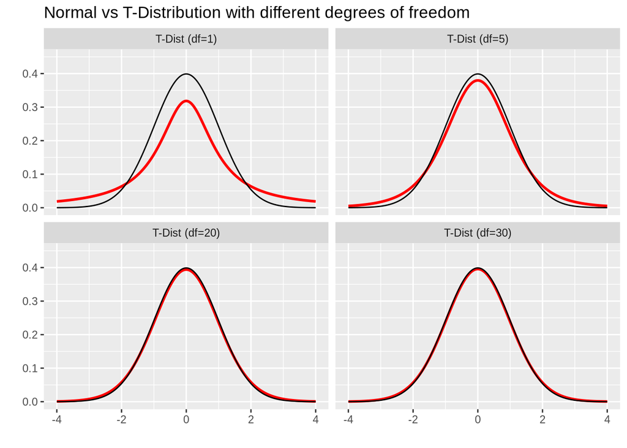

You are a wellness advocate interested in the amount of sleep students are getting. In particular, you want to estimate the population mean of all the numbers of hours slept by college students the night before finals. To estimate this population mean, you select a random sample of 19 college students and record the number of hours each student slept the night before finals. Assume that the population is approximately normally distributed.

Based on your sample *(n = 19, $\bar{X}$ = 6.556, S = 2.018)*, construct a 95% confidence interval for the population mean of all the numbers of hours slept by college students the night before finals.

- We know that $\sigma$ is UNKNOWN, the sample mean is from a simple random sample and the population is approximately normal. **Caution:** If the population is NOT approximately normal, make sure the sample size is large (n > 30).
- Formula: $\bar{X} \pm (T_{critical})(\frac{S}{\sqrt{n}})$
- $6.556 \pm (T_{critical})(\frac{2.018}{\sqrt{19}})$
- In ALEKS calculator, use the function **t_** to find the $T_{critical}$ value for a 95% confidence interval.
- Type: $t_{0.025,df=18}$
- The first argument in the ALEKS function **t_** specifies the “right tail area” in the Student’s T distribution when the middle area (confidence level percentage) is 0.95 (or 95%).
- The second argument refers to the number of degrees of freedom, n - 1.
- The $T_{critical}$ for this exercise is 2.10.
- $6.556 \pm (2.10)(\frac{2.018}{\sqrt{19}})$
- Lower limit: 6.556 - (2.10)(0.463) = 5.58
- Upper limit: 6.556 + (2.10)(0.463) = 7.53
- I am 95% confident that the average numbers of hours slept by college students the night before finals is between 5.58 and 7.53 hours.

# Confidence Intervals in R

A corporation that maintains a large fleet of company cars for the use of its sales staff is interested in the mean distance driven monthly per salesperson. The following list gives the monthly distances in miles driven by a random sample of 15 salespeople: 2410, 2414, 2468, 2419, 1958, 2579, 2314, 2690, 2293, 2019, 2066, 2177, 2309, 1954, 2094.

Based on this sample, find a 99% confidence interval for the mean number of miles driven monthly by members of the sales staff, assuming that monthly driving distances are normally distributed. Give the lower limit and upper limit of the 99% confidence interval.

**Enter Data in R**

> Step 1: Open R GUI: library(Rcmdr)

> Step 2: CLICK ON DATA > NEW DATA SET > Enter name for data set: **staff** > OK

> Step 3: Click “Add row” fifteen times because there are 15 observations.

> Step 4: Change the columns names from V1 to **dist**.

> Step 5: Enter the corresponding data *(see above)* like you do in Excel. When you finish, click OK.

**Compute the Confidence Interval**

> Step 6: STATISTICS > MEANS > SINGLE-SAMPLE T-TEST

> Step 7: Select the variable: dist

> Step 8: Confidence Level: 0.99 > OK

```
    One Sample t-test

data:  miles
t = 38.947, df = 14, p-value = 1.125e-15
alternative hypothesis: true mean is not equal to 0
99 percent confidence interval:
 2103.514 2451.686
sample estimates:
mean of x
   2277.6
```

**Using Calculator**

Compute the sample mean and sample standard deviation.

> $\bar{X}$ = 2277.6, S = 226.492

Identify appropriate formula.

> Since $\sigma$ is UNKNOWN and random sample is from a normal distribution use $\bar{X} \pm T_{crit}\frac{S}{\sqrt{n}}$

Identify confidence level and degrees of freedom for computation of the $T_{crit}$ value.

> In ALEKS calculator type $t_{0.005,df=14}$

Step 4: Plug in values in the formula to find lower and upper limits.

> 2277.6 $\pm$ $(2.977)\frac{226.492}{\sqrt{15}}$

> Lower limit: 2277.6 - (2.977)(58.479) = 2103.51

> Upper limit: 2277.6 + (2.977)(58.479) = 2451.69

**Interpretation:** I am 99% confident that the mean number of miles driven monthly by members of the sales staff is between 2103.51 and 2451.69 miles.